# Modeling Cases of Mosquito-Borne Disease Using Persistent Homology

### Background

In 2015, Zika virus (ZIKV) was first introduced and spread across Brazil due to a plethora of *Aedes aegypti* mosquitoes.[^1] These species transmit ZIKV to people, which can cause mild symptoms or even severe health conditions such as Guillain-Barre’ Syndrome and microcephaly.[^2][^3] Derek Lo and Briton Park (2018) modeled the spread of ZIKV using linear regression, while comparing results between two models — one with predictors calculated from persistent homology (PH) and one without.[^4] They show that using the number of 0-dimensional and 1-dimensional homological features and the maximum lifetime (persistence) of any 1-dimensional feature can better predict the number of ZIKV cases in Brazil.

In our example, we will demonstrate how to use these topological features to model disease transmission by *Aedes aegypti*, similar to the ZIKV model built by Lo and Park.

### Methods

To imitate the model from Lo and Park with available data, we will predict the number of ZIKV cases confirmed in each state through linear regression. However, data points of *aegypti* mosquitoes in Brazil are only available for the year 2013, while documented ZIKV cases are available only since 2015. Instead of using the number of ZIKV cases as the response variable in our regression model, we obtained the number of Dengue cases in Brazil for the year 2013,[^5] since Dengue is also transmitted by *Aedes aegypti* mosquitoes. Predictions of number of cases in each state will be made using average temperatures, precipitation levels,[^6] and human population densities.[^7][^8] Notice that the source for temperature data provided by Lo and Park is no longer available. The accessible dataset for temperatures and precipitations are averaged throughout multiple years, thus it may not be completely accurate for 2013.

In addition to these state-level attributes, we will utilize spatial information on *Aedes aegypti* occurrences.[^9] We include the number of 0-dimensional features (H0) as a predictor since a higher value of H0 indicates that a state harbors more mosquitoes. We also include the number of 1-dimensional features (H1) in our model, as we interpret a larger value of H1 to mean that *Aedes aegypti* mosquitoes are more spread out. In addition, extending the analysis of Lo and Park, we include the maximum lifetime (H1ML) and the median lifetime (H1MD) of the 1-dimensinoal features, which we expect give additional insight into the statewide connectivity of *Aedes aegypti* distributions. A high H1ML indicates mosquitoes have a wider spread and are less clustered at a small number of specific regions. Also, we are curious about whether the median of H1 lifetime can improve upon the effect of H1ML demonstrated by Lo and Park.

### Datasets

First, we load the dataset `aegypti` containing geographic locations of *aegypti* mosquitoes. Also, we load the `zikaPredict` data to obtain human population density, average temperature, precipitation level, and the number of cases in each state.

We will use state abbreviations to join elements from these two data sets, and from the PH calculations. The vector `stateAbbSort`, de-duplicated from the *aegypti* dataset, provides a convenient tool for these tasks.

```r
devtools::load_all()
data(aegypti)
data(zikaPredict)

stateAbbSort <- sort(aegypti$state_code[!duplicated(aegypti$state_code)])
```

We will incrementally add the predictive variables to the data frame `zikaModel`.

```r
zikaModel <- data.frame()
```

### Persistent homology

Before building the model, following code provides an example of using Vietoris–Rips filtration on the mosquito occurrence patterns for a single state. First, we retrieve occurrence coordinates in the state of Acre (AC) from the *Aedes aegypti* dataset. Applying the `vietoris_rips` function to these coordinates, we receive a data frame that contains the birth and death information of every 0-dimensional (H0) and 1-dimensional (H1) feature. We plot these *persistence data* in the following graph, where the x-axis and y-axis represent the birth and death of each feature.

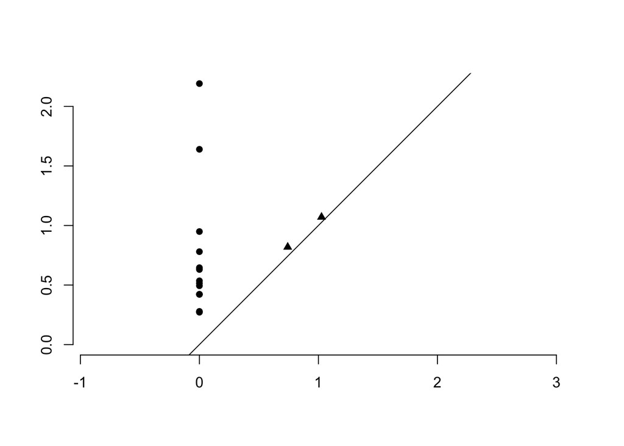

```r
AC_coord <- aegypti[aegypti$state_code == "AC", c("x", "y"), drop = FALSE]
AC_rips <- vietoris_rips(AC_coord) ##filtration

plot.new()
plot.window(
  xlim = c(0, max(AC_rips$death)),
  ylim = c(0, max(AC_rips$death)),
  asp = 1
)
axis(1L)
axis(2L)
abline(a = 0, b = 1)
points(AC_rips[AC_rips$dimension == 0L, c("birth", "death")], pch = 16L)
points(AC_rips[AC_rips$dimension == 1L, c("birth", "death")], pch = 17L)
```

For reference, we can also plot the mosquito occurrences based on their latitudes and longitudes in the *aegypti* dataset. Note, however, that the plot is not exactly faithful to the geography, since the distances between longitude lines vary from location to location. (This also means that our PH calculations are not exactly right. The same limitation applies to the analysis of Lo and Park.)

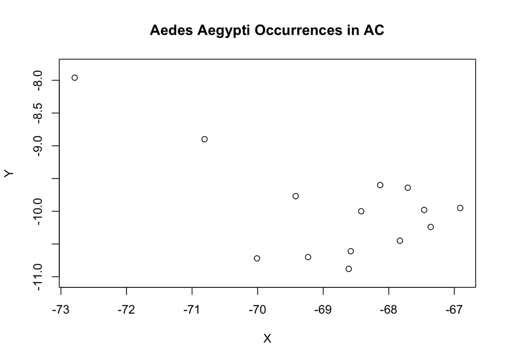

```r
plot(x = AC_coord$x, y = AC_coord$y, asp = 1, xlab = "X", ylab = "Y",
     main = "Aedes Aegypti Occurrences in AC")
```

The following function takes in a single state’s persistence data and returns a vector consisting of the values H0, H1, H1ML, and H1MD.

```r
topologicalFeatures <- function(state_rips){
  numH0 <- length(which(state_rips$dimension == 0))
  numH1 <- length(which(state_rips$dimension == 1))
  if (numH1 != 0) {
    maxPerst <- max(state_rips$persistence[(numH0 + 1) : (numH0 + numH1)])
    medianPerst <- median(state_rips$persistence[(numH0 + 1) : (numH0 + numH1)])

  } else {
    maxPerst <- 0
    medianPerst <- 0
  }
  return(c(numH0, numH1, medianPerst, maxPerst))
}
```

Iterating over all the states in Brazil, we bind every state’s topological features to `zikaModel`.

```r
for(val in stateAbbSort) {
  state_coord <- aegypti[aegypti$state_code == val, c("x", "y"), drop = FALSE]
  state_rips <- vietoris_rips(state_coord)
  state_rips$persistence<-(state_rips$death - state_rips$birth)

  features <- topologicalFeatures(state_rips)
  zikaModel <- rbind(
    zikaModel,
    c(features[1], features[2], features[3], features[4])
  )
}
colnames(zikaModel) <-  c("H0", "H1", "H1MD","H1ML")
rownames(zikaModel) <- stateAbbSort
```

We merge `zikaModel` with `zikaPredict`, matched by state code. Now we have loaded all potential predictors to our model. The following code prints out first few lines of the `zikaModel` to demonstrate how states and their variables lie within this data frame.

```r
zikaModel <- merge(zikaModel, zikaPredict, by = "row.names")[, -1]
rownames(zikaModel) <- stateAbbSort
head(zikaModel)
```

```
##     H0  H1       H1MD       H1ML        POP     TEMP    PRECIP  CASE
## AC  13   2 0.06063392 0.07681639   4.729529 25.66136 169.20068  2568
## AL 101  29 0.03059555 0.12310635 118.607876 24.67370  96.40583 11296
## AM  29   3 1.24451720 1.24898089   2.442278 26.49226 198.98254 17832
## AP  12   1 0.28318879 0.28318879   5.158925 26.22867 224.78617  1708
## BA 412 147 0.04711213 0.31302836  26.638086 23.88865  80.96277  6111
## CE 179  63 0.04965020 0.27650333  58.958386 26.22163  78.03878 30219
```

### Cases Visualization

Plots below visualize the number of cases within each state. To reproduce the model by Lo and Park, we will use the log-transformation on the number of cases to reduce skewness of the data and the influence of outliers.

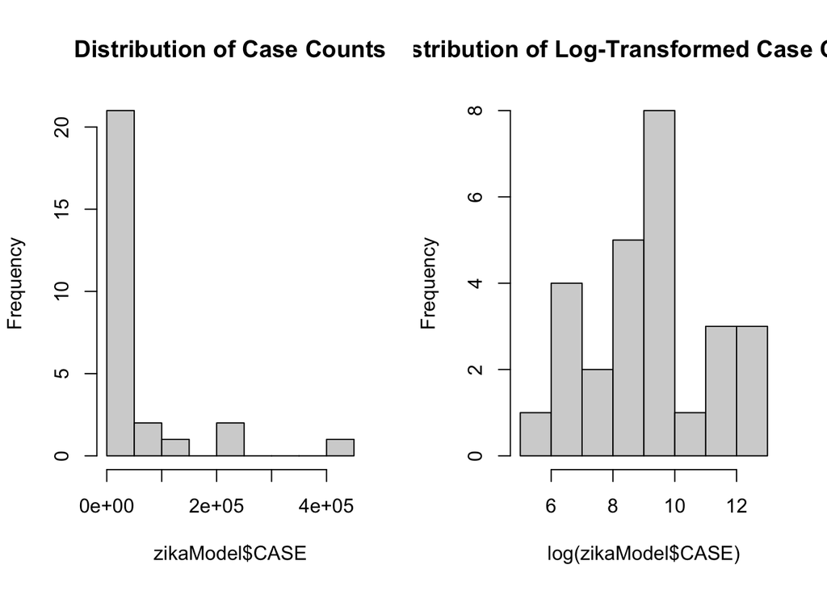

```r
par(mfrow = c(1L, 2L))

hist(zikaModel$CASE, main = "Distribution of Case Counts")

hist(log(zikaModel$CASE),
     main = "Distribution of Log-Transformed Case Counts")
```

We use the following plot to check if there is any correlation between predictors. We see that H0 and H1 are linearly related to each other, so H1 may not be a necessary predictor. During the model selection process, there will be a comparison about whether or not to include H1 as a predictor, and decisions will be made there.

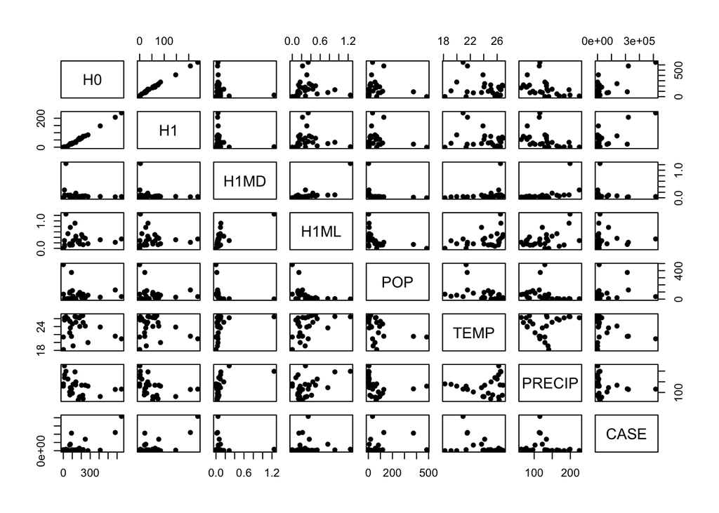

```r
pairs(zikaModel, pch = 16L)
```

### First fit: Model without Topological Features

First, we fit a linear model to log-transformed case counts predicted by population, temperature, precipitation, and H0 (the number of *aegypti* occurrences). Based on the summary output, the null hypothesis of no predictive value is rejected ($p = 0.0199$).

```r
fit.1 <- lm(log(CASE) ~ POP + TEMP + PRECIP + H0, data = zikaModel)
summary(fit.1)
```

```
##
## Call:
## lm(formula = log(CASE) ~ POP + TEMP + PRECIP + H0, data = zikaModel)
##
## Residuals:
##     Min      1Q  Median      3Q     Max
## -2.3891 -1.1671 -0.1294  0.7238  3.3588
##
## Coefficients:
##             Estimate Std. Error t value Pr(>|t|)
## (Intercept) 1.416851   4.061618   0.349  0.73053
## POP         0.007909   0.003406   2.322  0.02988 *
## TEMP        0.238266   0.144471   1.649  0.11331
## PRECIP      0.001867   0.008762   0.213  0.83324
## H0          0.007375   0.002306   3.198  0.00415 **
## ---
## Signif. codes:  0 '***' 0.001 '**' 0.01 '*' 0.05 '.' 0.1 ' ' 1
##
## Residual standard error: 1.634 on 22 degrees of freedom
## Multiple R-squared:  0.399,  Adjusted R-squared:  0.2898
## F-statistic: 3.652 on 4 and 22 DF,  p-value: 0.0199
```

To check error assumptions for linear regression, we plot residuals vs. fitted values and theoretical quantiles vs. standardized residuals. We observe that residuals for each fitted values are evenly distributed above and below the mean 0, and the relationship between residuals and fitted values seem to have a linear relation. In the qauntile-quantile plot, standardized residuals closely line up with normal values, with a few outliers. Therefore, the normal distribution assumption on error term is satisfied.

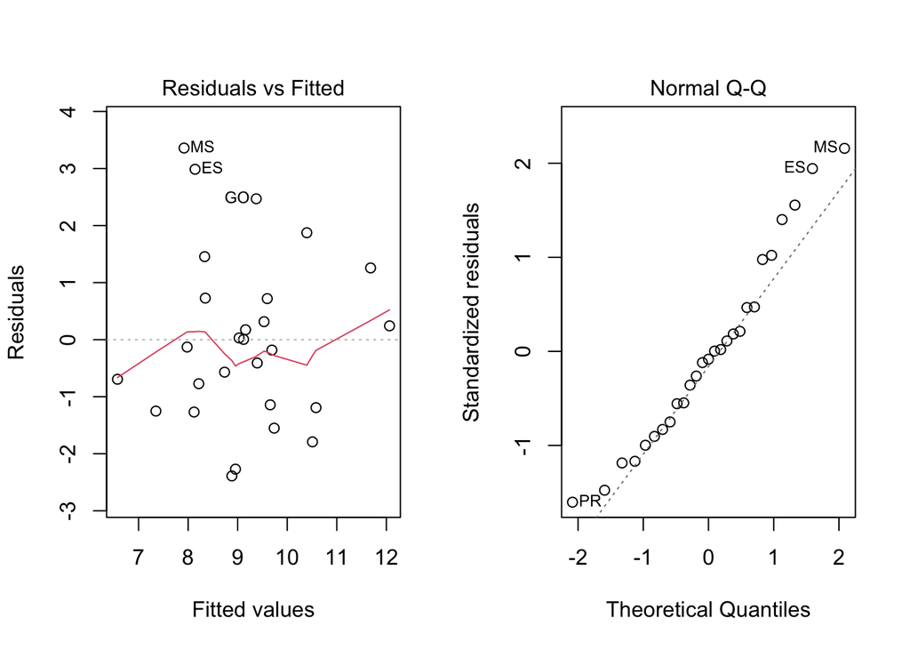

```r
par(mfrow = c(1L, 2L))
plot(fit.1, which = 1)
plot(fit.1, which = 2)
```

Next, we use the likelihood ratio test (LRT) to assess if we should drop the precipitation predictor `PRECIP`. In the LRT, $p = 0.8135$, which fails to reject the nested model. This result suggests that the simpler model without `PRECIP` is better. We therefore replace the original model with this more parsimonious one. Even though `TEMP` is not statistically significant, we keep it to the model as temperature is an effectual predictor in most epidemiology modeling, and one whose point estimate we may want to be able to report.

```r
fit.nested <- lm(log(CASE) ~ POP + TEMP + H0, data = zikaModel)
lmtest::lrtest(fit.nested, fit.1)
```

```
## Likelihood ratio test
##
## Model 1: log(CASE) ~ POP + TEMP + H0
## Model 2: log(CASE) ~ POP + TEMP + PRECIP + H0
##   #Df  LogLik Df  Chisq Pr(>Chisq)
## 1   5 -48.834
## 2   6 -48.807  1 0.0557     0.8135
```

```r
fit.1 <- lm(log(CASE) ~ POP + TEMP + H0, data = zikaModel)
summary(fit.1)
```

```
##
## Call:
## lm(formula = log(CASE) ~ POP + TEMP + H0, data = zikaModel)
##
## Residuals:
##     Min      1Q  Median      3Q     Max
## -2.3757 -1.1723 -0.0940  0.6976  3.3161
##
## Coefficients:
##             Estimate Std. Error t value Pr(>|t|)
## (Intercept) 1.771317   3.627567   0.488  0.62997
## POP         0.007684   0.003170   2.424  0.02362 *
## TEMP        0.235534   0.140883   1.672  0.10811
## H0          0.007161   0.002032   3.524  0.00182 **
## ---
## Signif. codes:  0 '***' 0.001 '**' 0.01 '*' 0.05 '.' 0.1 ' ' 1
##
## Residual standard error: 1.6 on 23 degrees of freedom
## Multiple R-squared:  0.3978, Adjusted R-squared:  0.3193
## F-statistic: 5.065 on 3 and 23 DF,  p-value: 0.007721
```

### Second fit: Model with Topological Features

```r
fit.2 <- lm(log(CASE) ~ POP + TEMP + H0 + H1 + H1ML + H1MD,
            data = zikaModel)
summary(fit.2)
```

```
##
## Call:
## lm(formula = log(CASE) ~ POP + TEMP + H0 + H1 + H1ML + H1MD,
##     data = zikaModel)
##
## Residuals:
##    Min     1Q Median     3Q    Max
## -2.014 -1.151  0.246  0.577  3.068
##
## Coefficients:
##              Estimate Std. Error t value Pr(>|t|)
## (Intercept)  3.228176   3.473642   0.929  0.36380
## POP          0.009529   0.003143   3.032  0.00659 **
## TEMP         0.155718   0.138196   1.127  0.27317
## H0          -0.021864   0.023392  -0.935  0.36109
## H1           0.078002   0.063214   1.234  0.23153
## H1ML         3.632102   1.767727   2.055  0.05321 .
## H1MD        -1.377716   1.941589  -0.710  0.48615
## ---
## Signif. codes:  0 '***' 0.001 '**' 0.01 '*' 0.05 '.' 0.1 ' ' 1
##
## Residual standard error: 1.508 on 20 degrees of freedom
## Multiple R-squared:  0.5348, Adjusted R-squared:  0.3952
## F-statistic: 3.832 on 6 and 20 DF,  p-value: 0.01049
```

Similarly, two plots below exhibit that error terms from the regression model are centered around 0 and normally distributed. There are a few outliers from the Q-Q plot, but their effects are trivial in our regression model.

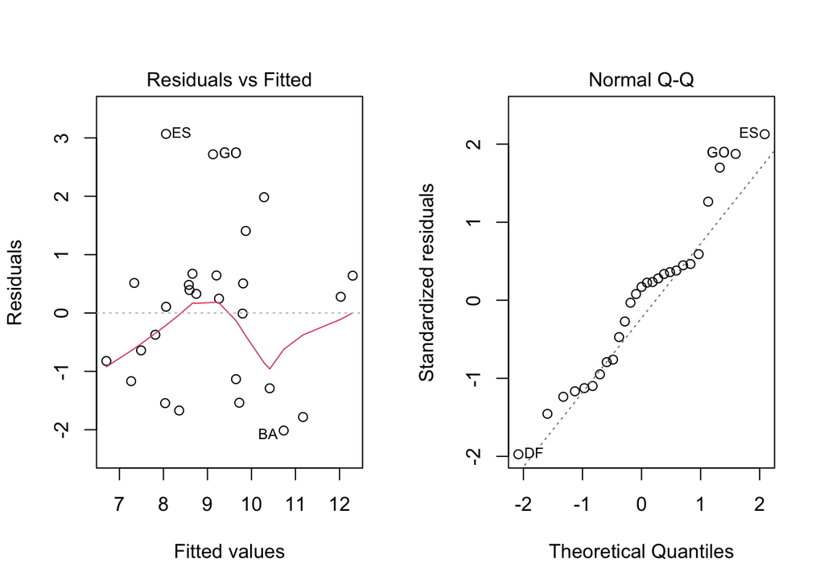

```r
par(mfrow = c(1L, 2L))
plot(fit.2, which = 1)
plot(fit.2, which = 2)
```

Using LRT to see if `H1MD` is a useful predictor, we fail to reject the nested model when H1MD is absent ($p = 0.4126$). Therefore, we leave out `H1MD` in our model.

```r
fit.test0 <- lm(log(CASE) ~ POP + TEMP + H0 + H1 + H1ML,
                data = zikaModel)
summary(fit.test0)
```

```
##
## Call:
## lm(formula = log(CASE) ~ POP + TEMP + H0 + H1 + H1ML, data = zikaModel)
##
## Residuals:
##     Min      1Q  Median      3Q     Max
## -1.9994 -0.9372  0.1673  0.6046  3.0713
##
## Coefficients:
##              Estimate Std. Error t value Pr(>|t|)
## (Intercept)  3.121003   3.429087   0.910  0.37307
## POP          0.009399   0.003101   3.032  0.00635 **
## TEMP         0.160272   0.136405   1.175  0.25316
## H0          -0.017450   0.022281  -0.783  0.44226
## H1           0.067017   0.060560   1.107  0.28097
## H1ML         2.731668   1.216049   2.246  0.03557 *
## ---
## Signif. codes:  0 '***' 0.001 '**' 0.01 '*' 0.05 '.' 0.1 ' ' 1
##
## Residual standard error: 1.49 on 21 degrees of freedom
## Multiple R-squared:  0.5231, Adjusted R-squared:  0.4095
## F-statistic: 4.606 on 5 and 21 DF,  p-value: 0.005412
```

```r
lmtest::lrtest(fit.test0, fit.2)
```

```
## Likelihood ratio test
##
## Model 1: log(CASE) ~ POP + TEMP + H0 + H1 + H1ML
## Model 2: log(CASE) ~ POP + TEMP + H0 + H1 + H1ML + H1MD
##   #Df  LogLik Df  Chisq Pr(>Chisq)
## 1   7 -45.687
## 2   8 -45.351  1 0.6713     0.4126
```

We observe that coefficients of both H0 and H1 are not statistically significant. Also, it is concerning because the coefficient of H0 in the nested model above is negative, which means more mosquito occurrences tend to decrease the number of cases. We decide to test the model without `H1`, as it seems to correlate with H0 and cause confounding.

```r
fit.test1 <- lm(log(CASE) ~ POP + TEMP + H0 + H1ML, data = zikaModel)
summary(fit.test1)
```

```
##
## Call:
## lm(formula = log(CASE) ~ POP + TEMP + H0 + H1ML, data = zikaModel)
##
## Residuals:
##     Min      1Q  Median      3Q     Max
## -2.2853 -1.0814 -0.1371  0.6899  3.1475
##
## Coefficients:
##             Estimate Std. Error t value Pr(>|t|)
## (Intercept) 2.708512   3.426125   0.791  0.43765
## POP         0.009607   0.003111   3.089  0.00537 **
## TEMP        0.158410   0.137089   1.156  0.26027
## H0          0.007117   0.001902   3.742  0.00113 **
## H1ML        2.471004   1.199093   2.061  0.05135 .
## ---
## Signif. codes:  0 '***' 0.001 '**' 0.01 '*' 0.05 '.' 0.1 ' ' 1
##
## Residual standard error: 1.498 on 22 degrees of freedom
## Multiple R-squared:  0.4952, Adjusted R-squared:  0.4035
## F-statistic: 5.396 on 4 and 22 DF,  p-value: 0.003494
```

```r
lmtest::lrtest(fit.test1, fit.test0)
```

```
## Likelihood ratio test
##
## Model 1: log(CASE) ~ POP + TEMP + H0 + H1ML
## Model 2: log(CASE) ~ POP + TEMP + H0 + H1 + H1ML
##   #Df  LogLik Df  Chisq Pr(>Chisq)
## 1   6 -46.452
## 2   7 -45.687  1 1.5303     0.2161
```

The likelihood ratio test suggests that we need to choose the simpler model without `H1` ($p = 0.2161$). In this case, we only need H1ML as our topological predictor.

```r
fit.2 <- lm(log(CASE) ~ POP + TEMP + H0 + H1ML, data = zikaModel)
```

### Results

We compare regression summaries of our final first and second models and observe an improvement of the adjusted R-squared when adding `H1ML` as an additional predictor.

```r
summary(fit.1)
```

```
##
## Call:
## lm(formula = log(CASE) ~ POP + TEMP + H0, data = zikaModel)
##
## Residuals:
##     Min      1Q  Median      3Q     Max
## -2.3757 -1.1723 -0.0940  0.6976  3.3161
##
## Coefficients:
##             Estimate Std. Error t value Pr(>|t|)
## (Intercept) 1.771317   3.627567   0.488  0.62997
## POP         0.007684   0.003170   2.424  0.02362 *
## TEMP        0.235534   0.140883   1.672  0.10811
## H0          0.007161   0.002032   3.524  0.00182 **
## ---
## Signif. codes:  0 '***' 0.001 '**' 0.01 '*' 0.05 '.' 0.1 ' ' 1
##
## Residual standard error: 1.6 on 23 degrees of freedom
## Multiple R-squared:  0.3978, Adjusted R-squared:  0.3193
## F-statistic: 5.065 on 3 and 23 DF,  p-value: 0.007721
```

```r
summary(fit.2)
```

```
##
## Call:
## lm(formula = log(CASE) ~ POP + TEMP + H0 + H1ML, data = zikaModel)
##
## Residuals:
##     Min      1Q  Median      3Q     Max
## -2.2853 -1.0814 -0.1371  0.6899  3.1475
##
## Coefficients:
##             Estimate Std. Error t value Pr(>|t|)
## (Intercept) 2.708512   3.426125   0.791  0.43765
## POP         0.009607   0.003111   3.089  0.00537 **
## TEMP        0.158410   0.137089   1.156  0.26027
## H0          0.007117   0.001902   3.742  0.00113 **
## H1ML        2.471004   1.199093   2.061  0.05135 .
## ---
## Signif. codes:  0 '***' 0.001 '**' 0.01 '*' 0.05 '.' 0.1 ' ' 1
##
## Residual standard error: 1.498 on 22 degrees of freedom
## Multiple R-squared:  0.4952, Adjusted R-squared:  0.4035
## F-statistic: 5.396 on 4 and 22 DF,  p-value: 0.003494
```

`H0` and `H1ML` are both positively related to the number of cases in each state. A higher value of `H0` indicates more *Aedes aegypti* occurrences within the given state, so it leads to more confirmed cases. Since we include both `H0` and `H1ML` in the model, given a fixed number of *Aedes aegypti* occurrences, a more persistent cycle would predict more cases as disease outbreaks can involve more locations. To interpret this, we select three states with similar `H0` but different `H1ML` and compare their number of cases.

We choose states Pernambuco, Ceará, and Goiás for this example and print out `H0`, `H1ML`, `POP`, and `CASE` for each state. We observe that state Goiás has the largest `H1ML` and the most cases, while Pernambuco has the smallest `H1ML` and the least number of cases. To reduce the effect of `H0` on case numbers and `H1ML`, `H0` is fixed since `H0` for three selected states all fall into the range around 200.

```r
Example_States <- c("PE", "CE", "GO")
Coord_Example <- data.frame()
for(val in Example_States){
  targetRow <- zikaModel[rownames(zikaModel) == val,]
  Coord_Example <- rbind(Coord_Example,
                         c(targetRow$H0, targetRow$H1ML, targetRow$CASE))
}
rownames(Coord_Example) <- Example_States
colnames(Coord_Example) <- c("H0", "H1ML", "CASE");Coord_Example
```

```
##     H0      H1ML   CASE
## PE 184 0.1594328   7985
## CE 179 0.2765033  30219
## GO 245 0.3654354 139357
```

While controlling `H0`, we want to give a visualized interpretation of how `H1ML` positively relates to the number of cases. To achieve this, we plot *Aedes aegypti* occurrences on an xy-axis. We also limit the range of the x-axis to 10 in all three plots to fix the geographic dimension, in order to have a fair comparison between *aegypti* distributions.

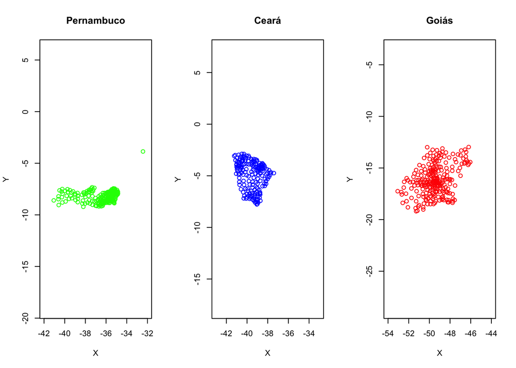

```r
par(mfrow = c(1L, 3L))

PE_coord <- aegypti[aegypti$state_code == "PE", c("x", "y"), drop = FALSE]
PE_rips <- vietoris_rips(PE_coord)
plot(x = PE_coord$x, y = PE_coord$y, asp = 1, col = "green",
     xlim = c(-42, -32), xlab = "X", ylab = "Y", main = "Pernambuco")

CE_coord <- aegypti[aegypti$state_code == "CE", c("x", "y"), drop = FALSE]
CE_rips <- vietoris_rips(CE_coord)
plot(x = CE_coord$x, y = CE_coord$y, asp = 1, col = "blue",
     xlim = c(-43, -33), xlab = "X", ylab = "Y", main = "Ceará")

GO_coord <- aegypti[aegypti$state_code == "GO", c("x", "y"), drop = FALSE]
GO_rips <- vietoris_rips(GO_coord)
plot(x = GO_coord$x, y = GO_coord$y, asp = 1, col = "red",
     xlim = c(-54, - 44), xlab = "X", ylab = "Y", main = "Goiás")
```

```r
par(mfrow = c(1L, 1L))
```

### Discussions

We have shown that using topological features from *Aedes aegypti* occurrences, in conjunction with standard epidemiology variables, could better use the spatial information of existing data to benefit the prediction of ZIKV cases. Compared to using different years’ datasets by Lo and Park, we have kept all our datasets to 2013 so our model leads to a different result. Also, improvements in our regression model after using topological features are not extraordinarily significant. In addition to variables included in our model, it is possible to further involve interaction terms, quadratic predictors, and log transformation of topological features when they are contextually and statistically appropriate. We have tested our model while incorporating the interaction between `H1` and `H1ML` as an additional predictor, in order to follow the approach by Lo and Park. But this interaction term is not significant and does not contribute to the overall fitness of our model. Even though variable selections and results seem a little to deviate from the regression model built by Lo and Park, our model demonstrates how to take advantage of topological features generated by the Vietoris-Rips filtration.

### References

[^1]: Gatherer D and Kohl A. Zika virus, a previously slow pandemic spreads rapidly through the Americas. Journal of General Virology. 2016 97: 269–273. https://doi.org/10.1099/jgv.0.000381 PMID: 26684466
[^2]: Winer J. An update in Guillain-Barre´ Syndrome. Autoimmune Diseases. 2014. https://doi.org/10.1155/ 2014/793024 PMID: 24511391
[^3]: Johansson MA, Mier-y-Teran-Romero L, Reefhuis J, Gilboa S and Hills S. Zika and the risk of microcephaly. N Engl J Med. 2016 375: 1–4. https://doi.org/10.1056/NEJMp1605367 PMID: 27222919
[^4]: Lo D, Park B (2018) Modeling the spread of the Zika virus using topological data analysis. PLoS ONE 13(2): e0192120. https://doi.org/10.1371/journal.pone.0192120
[^5]: Brazil Ministry of Health. 2014. Boletim Epidemiológico. ISSN 2358-9450. https://web.archive.org/web/20210209122713/https://www.gov.br/saude/pt-br/assuntos/boletins-epidemiologicos-1/por-assunto
[^6]: Ipeadata. http://www.ipeadata.gov.br/Default.aspx
[^7]: Brazilian Institute of Geography and Statistics. 2015. Retrieved from https://ftp.ibge.gov.br/Estimativas_de_Populacao/
[^8]: Brazilian Institute of Geography and Statistics. 2020. https://www.ibge.Goiásv.br/geociencias/organizacao-do-territorio/estrutura-territorial/15761-areas-dos-municipios.html?edicao=30133&t=acesso-ao-produto
[^9]: Kraemer, Moritz U. G. et al. 2017. Data from: The global compendium of Aedes aegypti and Ae. albopictus occurrence, Dryad, Dataset, https://doi.org/10.5061/dryad.47v3c